# scMapping(single-cell mapping)

The goal of scMapping is to annotate cell clusters for single cell data.

## 1. Installation

You can install the development version of scMapping like so:

```r
# devtools::install_github("chloelulu/scMapping")
# pkgs <- c("ggplot2", "dplyr","tidyr","tibble","reshape2")
# new.packages <- pkgs[!(pkgs %in% installed.packages()[,"Package"])]
# if(length(new.packages)) install.packages(new.packages)
```

```r
pkgs <- c("ggplot2", "dplyr","tidyr","tibble","reshape2")
sapply(pkgs, require, character.only = TRUE)
```

```
##  ggplot2    dplyr    tidyr   tibble reshape2
##     TRUE     TRUE     TRUE     TRUE     TRUE
```

```r
library(scMapping)
```

After you load the package, the demo “data” and integrated “scMappingDatabase” will be automatically loaded

```r
head(data)
```

```
##         p_val avg_log2FC pct.1 pct.2 p_val_adj cluster    gene
## Fabp4       0   4.358483 0.989 0.361         0       1   Fabp4
## Aqp1        0   4.054885 0.887 0.190         0       1    Aqp1
## Flt1        0   3.603298 0.929 0.109         0       1    Flt1
## Gpihbp1     0   3.333778 0.877 0.091         0       1 Gpihbp1
## Timp4       0   3.323238 0.854 0.089         0       1   Timp4
## Cdh5        0   3.298942 0.909 0.101         0       1    Cdh5
```

scMappingDatabase is the database integrated in the package. User can also supply their own database, should be in the same format as scMappingDatabase

```r
head(scMappingDatabase[,c(1:4)])
```

```
##           tissue          gene adipose tissue:Adipocyte
## 1 adipose tissue 2810025M15RIK                        0
## 2 adipose tissue 4931406P16RIK                        0
## 3 adipose tissue 9430020K01RIK                        0
## 4 adipose tissue          ABI2                        0
## 5 adipose tissue    AC009041.1                        0
## 6 adipose tissue    AC148011.4                        0
##   adipose tissue:Adipose-derived stem cell
## 1                                        0
## 2                                        0
## 3                                        0
## 4                                        0
## 5                                        0
## 6                                        0
```

## 2. Running scMapping

To annotate a scRNA-seq data analysis output generated by ‘FindAllMarkers’ function of Seurat[(Butler, A., et al.)](https://www.nature.com/articles/nbt.4096?report=reader)

```r
obj <- scmapping(data = data, database = scMappingDatabase, tissue = 'muscle')
```

scMapping also supplies a plot function to help you visualize the result. If “directory = NULL” plot will be automatically saved to the current working directory.

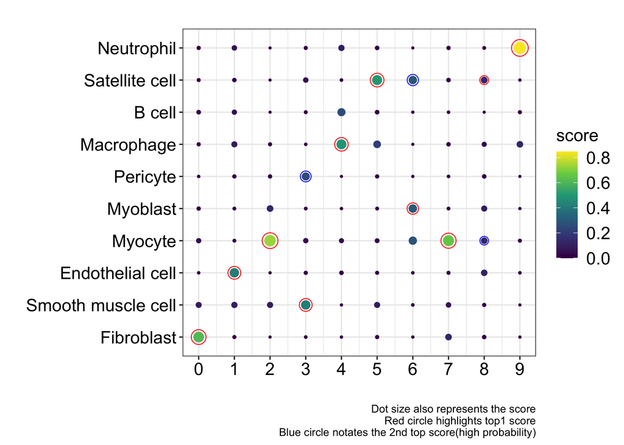

```r
plt <- scmapping.plot(scmapping.object = obj, directory = NULL)
```

## 3. Using scMapping start from Seurat

Below code illustrate how to use scMapping if you start with a Seurat analysis.

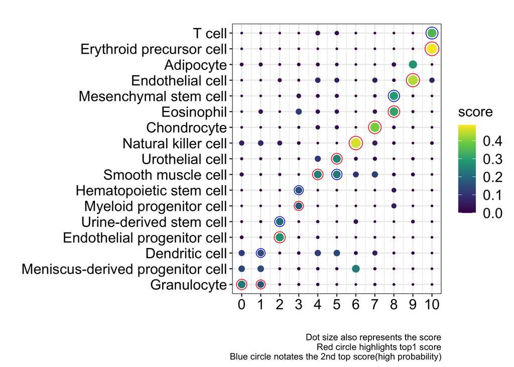

```r
library(SeuratData)
library(Seurat)
seurat.obj <- LoadData(ds = "pbmc3k")
seurat.obj <- NormalizeData(object = seurat.obj)
seurat.obj <- FindVariableFeatures(object = seurat.obj)
seurat.obj <- ScaleData(object = seurat.obj)
seurat.obj <- RunPCA(object = seurat.obj)
seurat.obj <- FindNeighbors(object = seurat.obj)
seurat.obj <- FindClusters(object = seurat.obj)
seurat.markers <- FindAllMarkers(seurat.obj, method = 'MAST')
scmapping.obj <- scmapping(data = seurat.markers, database=scMappingDatabase, tissue = 'blood')
plt <- scmapping.plot(scmapping.object = scmapping.obj, directory = NULL)
```

You can also extract the markers mapped by scMapping and making a dotplot. Below code visualize the genes mapped to cluster 0 (predicted cell type Granulocyte)

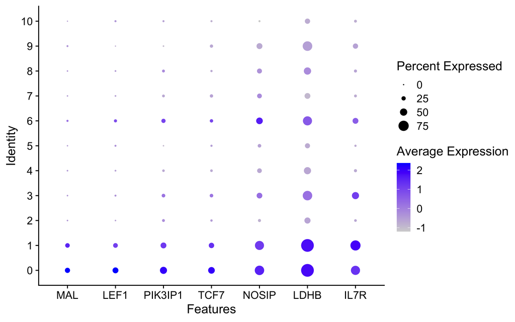

```r
gns <- scmapping.obj$markers$genes[scmapping.obj$markers$cluster==0 & scmapping.obj$markers$celltype=='Granulocyte']
gns <- strsplit(gns, ',')[[1]]
DotPlot(seurat.obj, features = gns)
```

# 4. References

- Lu Yang, Yan Er Ng, Haipeng Sun, Ying Li, Nathan LeBrasseur, Jun Chen, Xu Zhang. single-cell mapping (scMapping), an easy-to-use tool for mapping cell types in single-cell RNA-sequencing data analysis. In preparation